# First Course in R

Jeremy Ash

April 9, 2018

I am a fourth year Bioinformatics student in Dr. Fourches’s lab. I developed a R package called [chemmodlab](https://cran.r-project.org/web/packages/chemmodlab/index.html).

Some of these materials have been based on Brian Reich’s ST540 course materials available in the Introduction to R section [here](https://www4.stat.ncsu.edu/~reich/ABA/code.html).

# R Basics

## Basic arithmetic

You can do any basic arithmetic in R. It can be used as your personal calculator! Try submitting a few commands.

```r
(3-1)*4
```

```
## [1] 8
```

```r
2^4
```

```
## [1] 16
```

## Variables

Use the arrow operator to assign a value to a variable. All of these variables are stored as objects in your R Environment.

```r
x <- 2
```

You can see all of the objects that live in your environment.

```r
ls()
```

```
## [1] "x"
```

## Data structures

### Vectors

The most basic data structure in R is a vector. Numeric vectors can be constructed in a number of ways.

```r
x1 <- c(1,3,5,7)
x1
```

```
## [1] 1 3 5 7
```

```r
x2 <- 1:5
x2
```

```
## [1] 1 2 3 4 5
```

### Functions

Base R comes with a number of “functions” that will perform operations on objects in your environment. In most cases, these are just commands that are wrappers for more R code. Same of the base R functions are written in C.

```r
# Take a random sample of size 2 from x2
sample(x2, 2)
```

```
## [1] 1 4
```

```r
sample
```

```
## function (x, size, replace = FALSE, prob = NULL)
## {
##     if (length(x) == 1L && is.numeric(x) && is.finite(x) && x >=
##         1) {
##         if (missing(size))
##             size <- x
##         sample.int(x, size, replace, prob)
##     }
##     else {
##         if (missing(size))
##             size <- length(x)
##         x[sample.int(length(x), size, replace, prob)]
##     }
## }
## <bytecode: 0x0000000006054678>
## <environment: namespace:base>
```

Anytime you do not know how to use a function that you find on the internet, you can almost always find detailed documentation in R.

```r
?sum
# The ?? command will search for all functions that match a string
??colMeans
```

### More numeric vectors

Now a few other ways to create numeric vectors using functions…..

```r
x3 <- seq(10,15,0.5)
x3
```

```
##  [1] 10.0 10.5 11.0 11.5 12.0 12.5 13.0 13.5 14.0 14.5 15.0
```

```r
x4 <- rep(5,5)
x4
```

```
## [1] 5 5 5 5 5
```

### Other vector types

There are three main types of vectors: *numeric*, *character*, and *factor*.

```r
# numeric vectors
class(x1)
```

```
## [1] "numeric"
```

```r
x1
```

```
## [1] 1 3 5 7
```

```r
# character vectors
x5 <- c("foo", "bar")
class(x5)
```

```
## [1] "character"
```

```r
x5
```

```
## [1] "foo" "bar"
```

```r
# factor vectors
x6 <- as.factor(c("high", "mid", "low"))
class(x6)
```

```
## [1] "factor"
```

```r
x6
```

```
## [1] high mid  low
## Levels: high low mid
```

```r
as.numeric(x6)
```

```
## [1] 1 3 2
```

### Arithmetic operations on numeric vectors

Arithmetic operations occur on numeric vectors elementwise.

```r
x2*3
```

```
## [1]  3  6  9 12 15
```

```r
x2^2
```

```
## [1]  1  4  9 16 25
```

Vectors and be combined through arithmetic operation, if they are the same length.

```r
length(x1)
```

```
## [1] 4
```

```r
length(x2)
```

```
## [1] 5
```

```r
x12 <- x1+x2
# There was only a warning
# The sum of the first four elements of both vectors was returned
# See https://cran.r-project.org/doc/manuals/r-release/R-intro.html#The-recycling-rule for more details
x12
```

```
## [1]  2  5  8 11  6
```

```r
length(x2)
```

```
## [1] 5
```

```r
length(x4)
```

```
## [1] 5
```

```r
x2+x4
```

```
## [1]  6  7  8  9 10
```

### Matrices

A matrix is a two-dimensional object with rows and columns. Data are often stored as matrices where rows are observations and columns are variables.

Vectors can be combined to make a matrix.

```r
y <- cbind(x2,x4)
y
```

```
##      x2 x4
## [1,]  1  5
## [2,]  2  5
## [3,]  3  5
## [4,]  4  5
## [5,]  5  5
```

```r
dim(y)
```

```
## [1] 5 2
```

You can also fill a matrix with values in major column order.

```r
mat <- matrix(1:6,3,2)
mat
```

```
##      [,1] [,2]
## [1,]    1    4
## [2,]    2    5
## [3,]    3    6
```

# Cheminformatics example

## Load the Comma separated variable (CSV) data set

```r
df <- read.csv("C:/Users/jrash/ubuntu_share/Google Drive/FourchesLab/CH795/ERK2_3D_des_and_pki.csv")
class(df)
```

```
## [1] "data.frame"
```

The CSV was read as a data frame. A data frame is just like a matrix, except it can store multiple vector types in its rows/columns.

This data frame is way too big to look at it in the R environment.

```r
dim(df)
```

```
## [1] 34800     4
```

It is often helpful to just take a peak at the object to make sure it is structured the way you expect it to be.

```r
head(df)
```

```
##    Set Cst.Sigma VdWVolumes.WV pki
## 1 CSAR  3.640052      165.0452 4.8
## 2 CSAR  3.934088      157.2535 4.8
## 3 CSAR  3.995046      172.6868 4.8
## 4 CSAR  3.825216      158.6294 4.8
## 5 CSAR  3.883490      151.9165 4.8
## 6 CSAR  3.730805      141.3349 4.8
```

The dollar sign is used to extract vectors from the data frames columns.

```r
head(df$Set)
```

```
## [1] CSAR CSAR CSAR CSAR CSAR CSAR
## Levels: CSAR Model
```

```r
class(df$Set)
```

```
## [1] "factor"
```

```r
head(df$pki)
```

```
## [1] 4.8 4.8 4.8 4.8 4.8 4.8
```

```r
class(df$pki)
```

```
## [1] "numeric"
```

## Histograms

Make a histogram of each descriptor and pki.

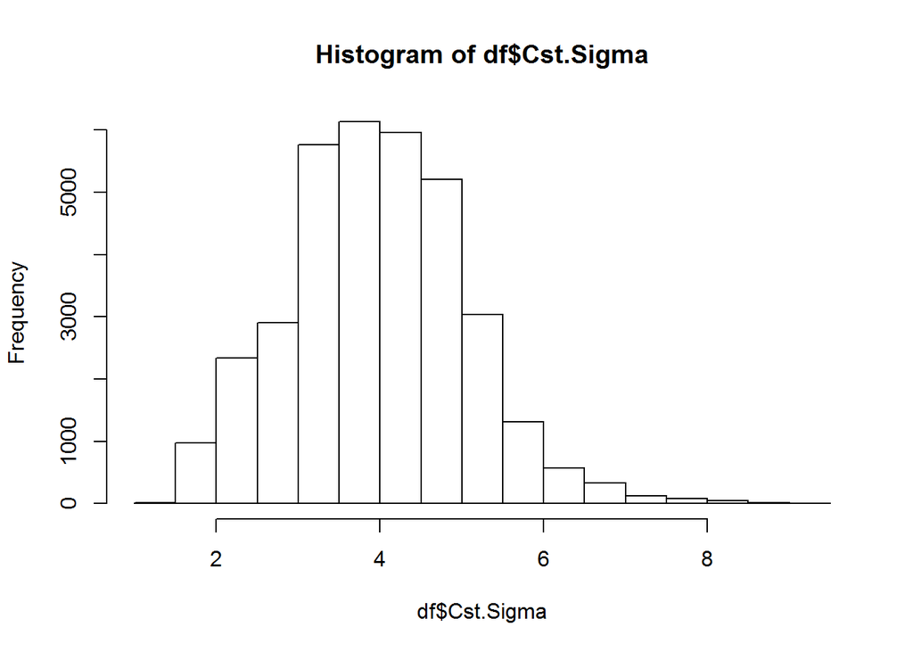

```r
hist(df$Cst.Sigma)
```

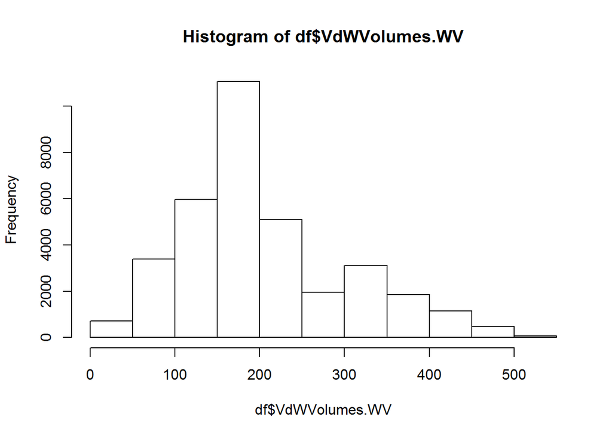

```r
hist(df$VdWVolumes.WV)
```

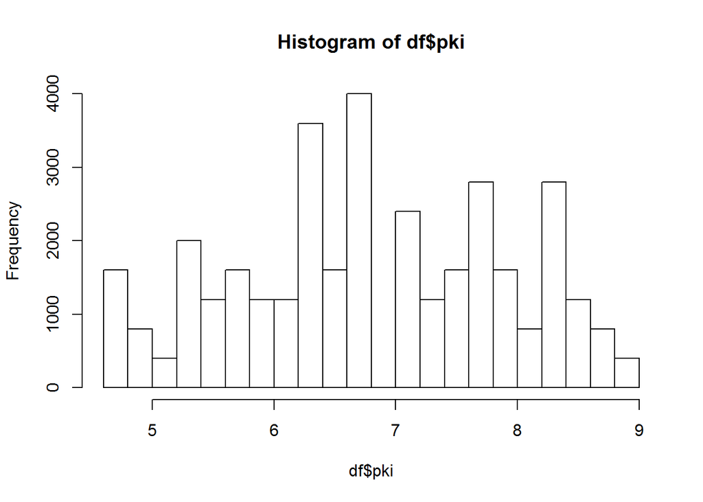

```r
hist(df$pki)
```

## Summary measures

Compute some summary measures of the Cst.Sigma descriptor.

```r
mean(df$Cst.Sigma)
```

```
## [1] 3.967396
```

```r
sd(df$Cst.Sigma)
```

```
## [1] 1.082533
```

```r
range(df$Cst.Sigma)
```

```
## [1] 1.418883 9.182595
```

Say we wanted to compute a new descriptor, the average of Cst.Sigma and VdWVolumes.WV.

```r
head((df$Cst.Sigma + df$VdWVolumes.WV)/2)
```

```
## [1] 84.34265 80.59379 88.34090 81.22729 77.90000 72.53285
```

## Plot the data

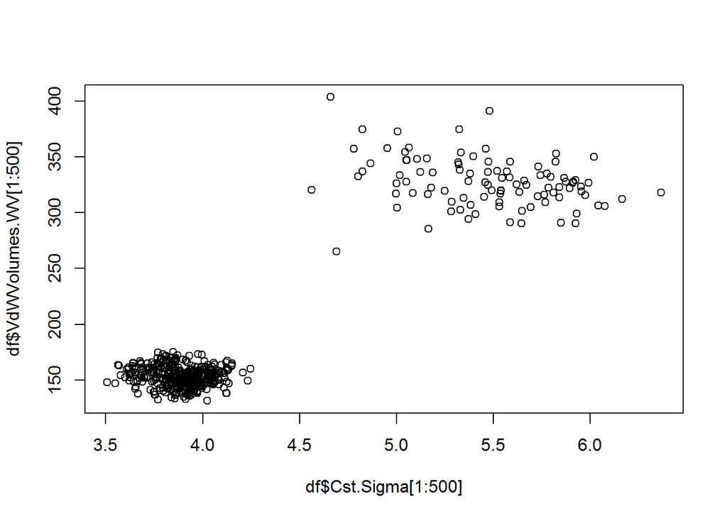

```r
plot(df$Cst.Sigma[1:500], df$VdWVolumes.WV[1:500])
```

We can modify a plot by passing options, such as the axis labels.

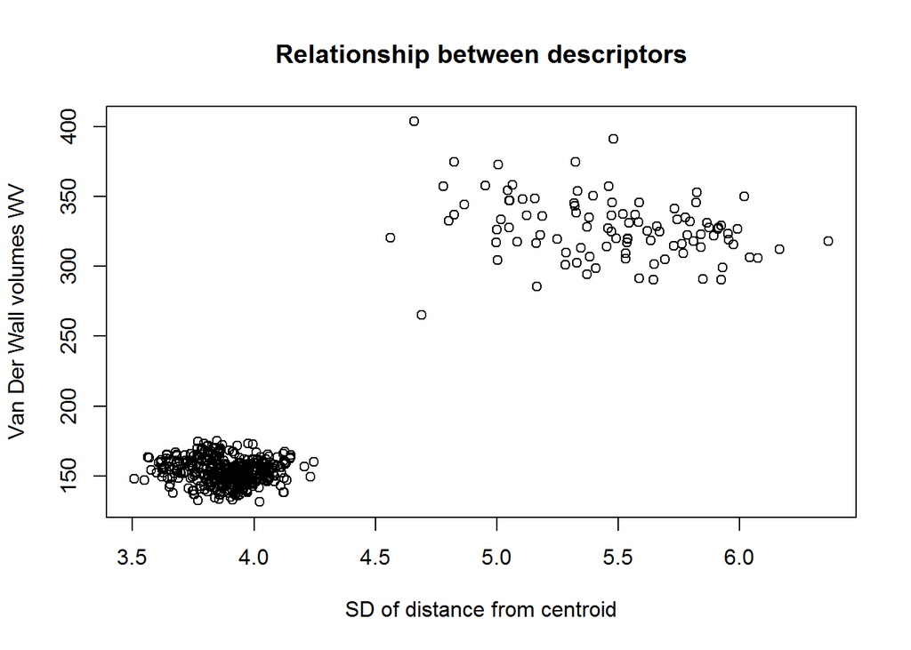

```r
plot(df$Cst.Sigma[1:500], df$VdWVolumes.WV[1:500],
     xlab="SD of distance from centroid",ylab="Van Der Wall volumes WV",
     main="Relationship between descriptors")
```

Now lets color ligand conformations by pki.

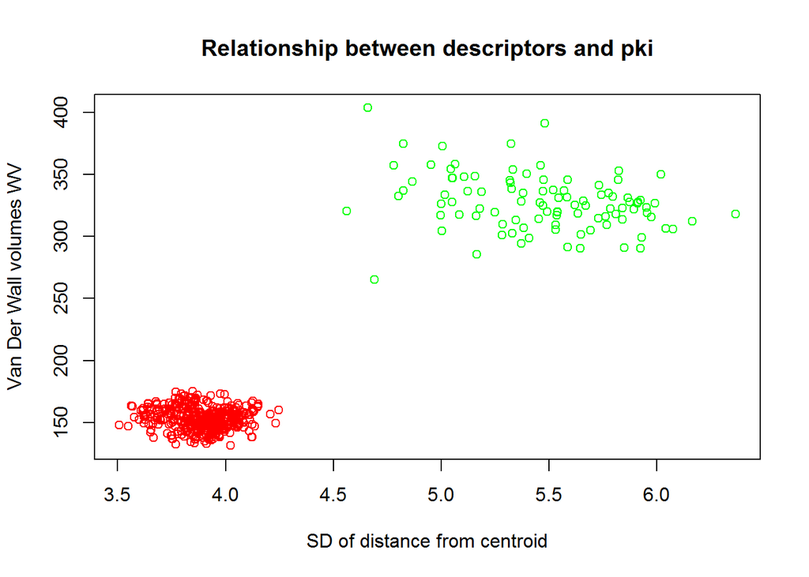

```r
colfunc <- colorRampPalette(c("red", "green"))
pki.col <- colfunc(2)[as.numeric(cut(df$pki,breaks = 2))]
plot(df$Cst.Sigma[1:500], df$VdWVolumes.WV[1:500],
     xlab="SD of distance from centroid",ylab="Van Der Wall volumes WV",
     main="Relationship between descriptors and pki",
     col = pki.col)
```

Lets plot the whole dataset!

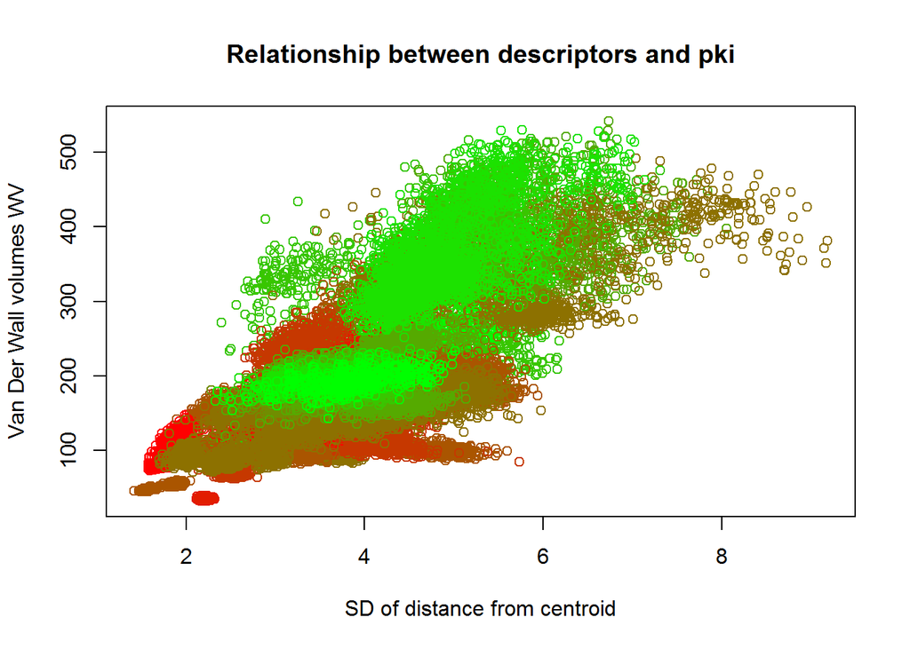

```r
pki.col <- colfunc(10)[as.numeric(cut(df$pki, breaks = 10))]
plot(df$Cst.Sigma, df$VdWVolumes.WV,
     xlab="SD of distance from centroid",ylab="Van Der Wall volumes WV",
     main="Relationship between descriptors and pki",
     col = pki.col)
```

There is a lot of overplotting going on here that is making the pattern in the data unclear. Lets try reducing the point size.

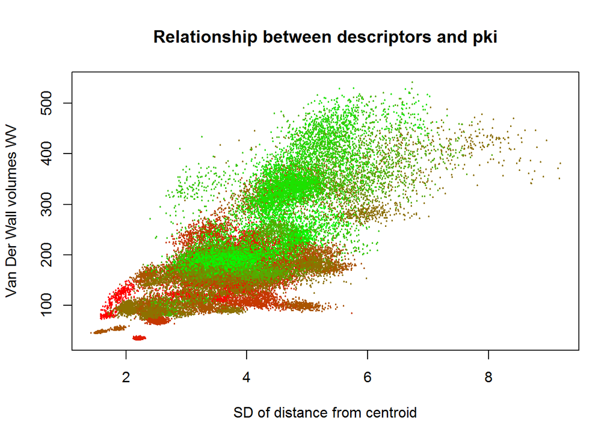

```r
pki.col <- colfunc(10)[as.numeric(cut(df$pki, breaks = 10))]
plot(df$Cst.Sigma, df$VdWVolumes.WV,
     xlab="SD of distance from centroid",ylab="Van Der Wall volumes WV",
     main="Relationship between descriptors and pki",
     col = pki.col, cex = .2)
```

And changing the plotted points from circles to points.

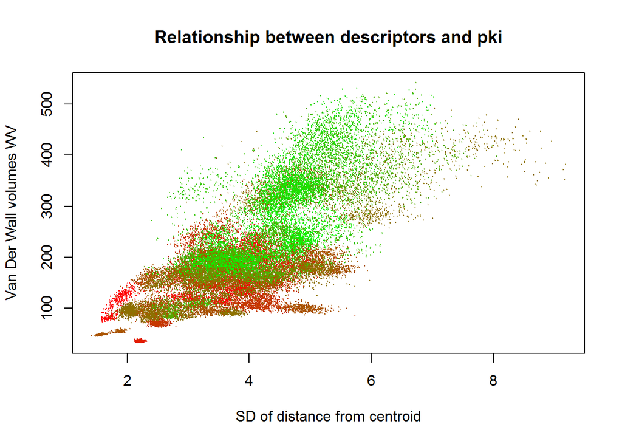

```r
pki.col <- colfunc(10)[as.numeric(cut(df$pki, breaks = 10))]
plot(df$Cst.Sigma, df$VdWVolumes.WV,
     xlab="SD of distance from centroid",ylab="Van Der Wall volumes WV",
     main="Relationship between descriptors and pki",
     col = pki.col, cex = .2, pch = 20)
```

You can make really pretty graphics using ggplot2. This is a library of functions that doesn’t come installed in base R. So you will need to install the library from the CRAN server and load into your workspace.

```r
install.packages("ggplot2")
```

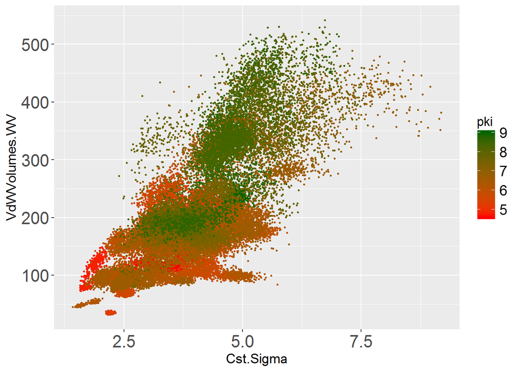

```r
library(ggplot2)
g <- ggplot(df, aes(x = Cst.Sigma, y = VdWVolumes.WV), alpha=.001)
g <- g + geom_point(aes(colour=pki), size=.5)
g <- g + scale_color_continuous(name = "pki",high='darkgreen', low='red')
g <- g + theme(title = element_text(size = rel(1.5)),
               axis.text=element_text(size = rel(1.5)),
               axis.title=element_text(size=rel(.8)),
               legend.title=element_text(size = rel(.75)),
               legend.text=element_text(size = rel(1.25)))

print(g)
```